# Homework #5 Key

Ch. 3 exercises 4 (only the first a and b), 5 (not a), and 8

4. a)

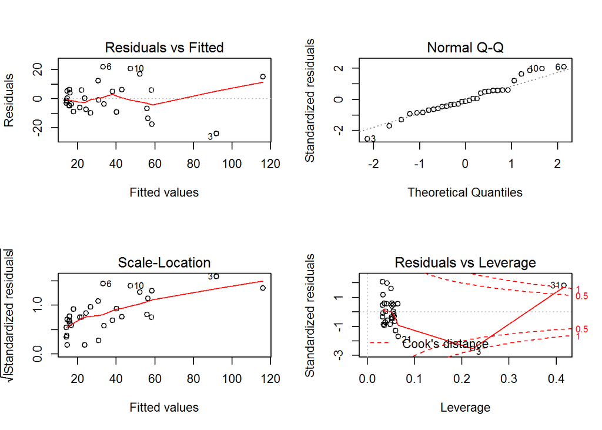

```r
glakes <- read.table("http://www.stat.tamu.edu/~sheather/book/docs/datasets/glakes.txt",
                     header = TRUE)
m1 <- lm(Time ~ Tonnage, data = glakes)
par(mfrow = c(2, 2))
plot(m1)
```

The primary problem with fitting a straigh-line regression model here on the raw data is that there is strongly increasing variance in the residuals. There are also signs of two highly influential points (3 and 31). The linear trend and the normality of the residuals seem like they are find assumptions, however. We might want to look into how the port operates to assess whether the observations are independent. We don’t know the units of time, but if these are long time spans that extend beyond blocks of operating hours, then the times could be dependent as ships wait on other ships to finish up within a block of time.

2. The interval would likely be too short. In `m1`, the variance is assumed constant, and that variance is estimated by using data from all ranges of x. We can see in the scale-location plot that the variance in the data at the higher ranges of x (around 10,000) is greater than average, so there would be more variance in the data than in our PI. This will result in a PI that is too short.
5. b)

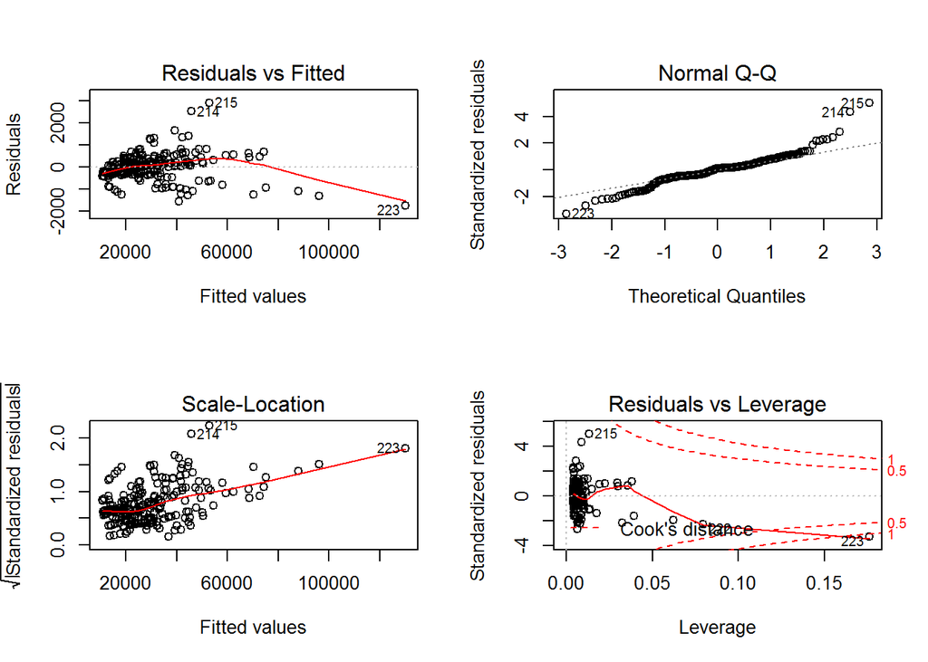

```r
cars04 <- read.csv("http://www.stat.tamu.edu/~sheather/book/docs/datasets/cars04.csv")
m1 <- lm(SuggestedRetailPrice ~ DealerCost, data = cars04)
par(mfrow = c(2, 2))
plot(m1)
```

This is a very problematic model. The scale location plot shows that we can strongly increasing variance in the residuals. The Cook’s Distance plot shows one point in particular (223) that is highly influential. The distribution of the residuals has longer tails that the normal distribution, calling into question the assumption of normally distributed errors. Finally, there is structure in the residual plot that suggests that the mean function is not well modeled with a straight line. We don’t have enough information about where the data come from to assess whether the independence assumption is reasonable.

c)

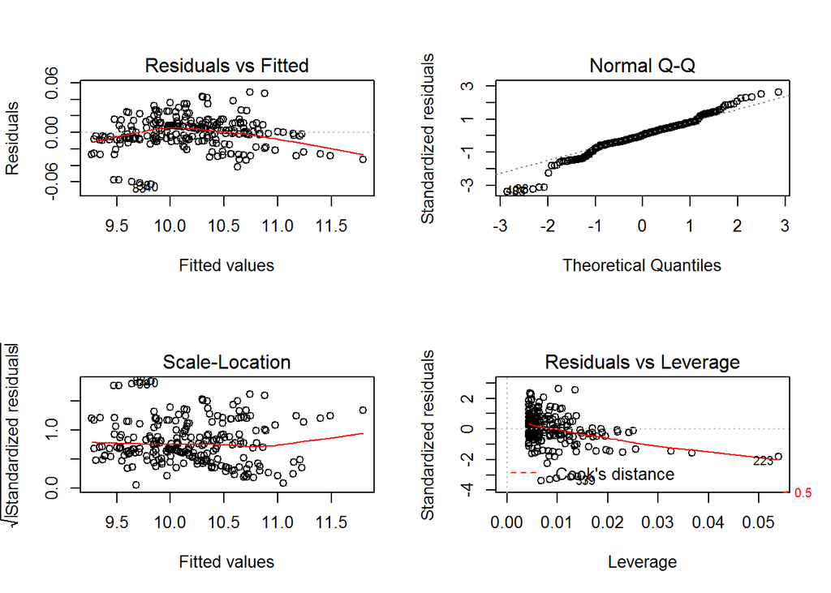

```r
cars04 <- transform(cars04,
                    logPrice = log(SuggestedRetailPrice),
                    logCost = log(DealerCost))
m2 <- lm(logPrice ~ logCost, cars04)
par(mfrow = c(2, 2))
plot(m2)
```

This model is a big improvement over the untransformed one. Most notably, the variance has stabilized and there are no longer any influential points.

4. Two cars that are separated by 1% in their dealer cost are expected to be separated by 1.0148% in their suggested retail price.
5. The left tail of the residuals is still longer than expected, so prediction intervals can be expected to be off. The most persistent problem, though, is the non-linear trend in the residuals, suggesting that a quadratic model might be an improvement.
8. **Part I** a)

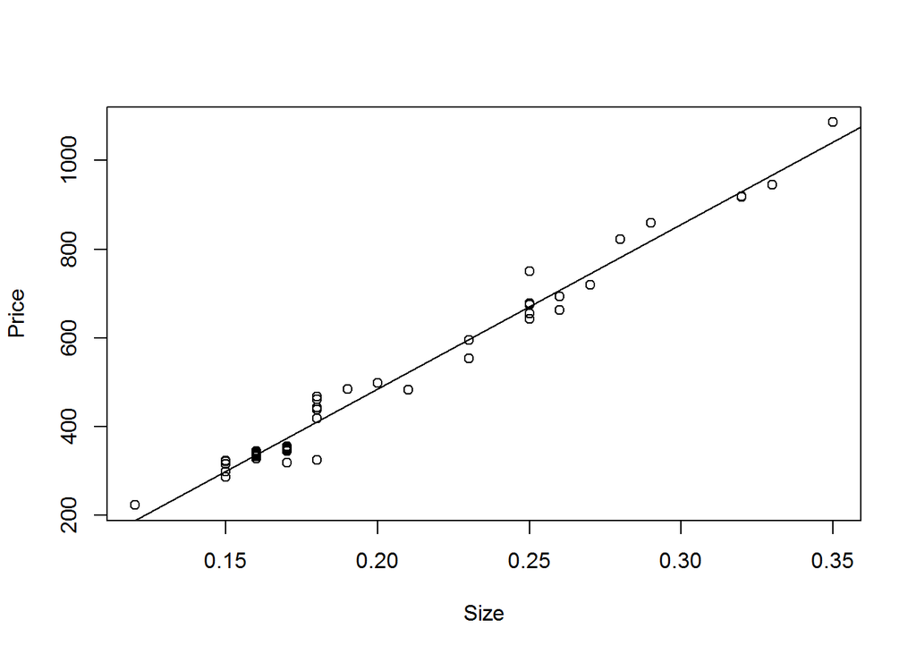

```r
diamonds <- read.table("http://www.stat.tamu.edu/~sheather/book/docs/datasets/diamonds.txt",
                       header = TRUE)
m1 <- lm(Price ~ Size, data = diamonds)
plot(Price ~ Size, data = diamonds)
abline(m1)
```

If we create a scatterplot to examine the relationship between the size and price of diamonds, we see that there is a clear positive and linear relationship with no apparent outliers. This is a good candidate for straight-line regression.

b)

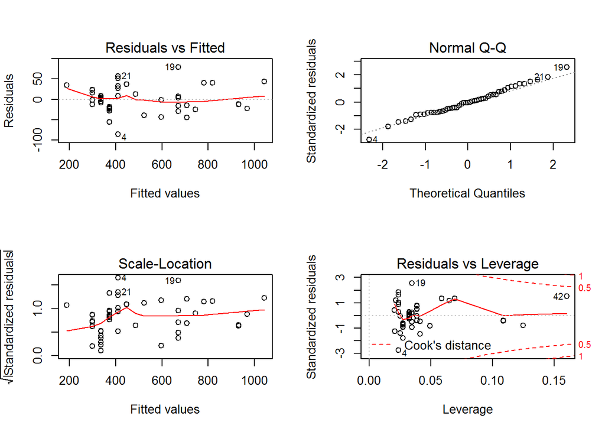

```r
par(mfrow = c(2, 2))
plot(m1)
```

Based on the scale location plot, there is some indication that the variance of the errors may be increasing with x. The residul plot shows no strong patterns, suggesting that the assumption of linearity is OK. Similarly, with the QQ plot the indicates that the normal error assumption is warranted. There are no highly influential points found in the Cook’s distance plot. It’s likely that each diamond is independent of the others unless the prices were set to add up to some fixed amount.

**Part II*

a)

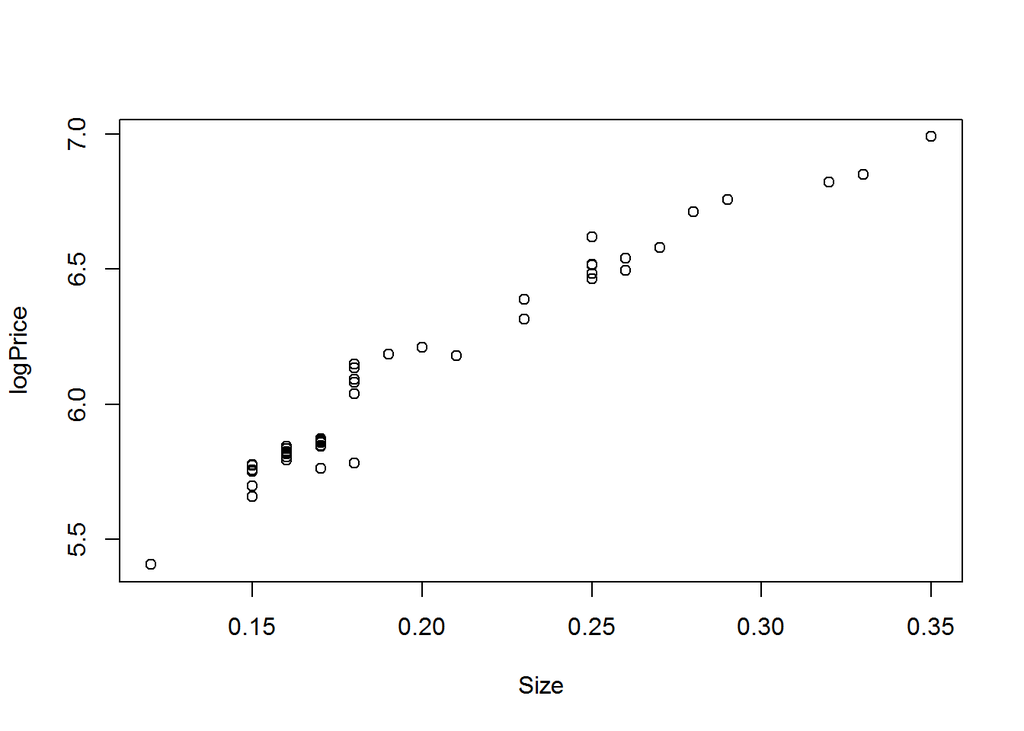

```r
diamonds <- transform(diamonds,
                      logSize = log(Size),
                      sqrtSize = sqrt(Size),
                      logPrice = log(Price),
                      sqrtPrice = sqrt(Price))
plot(logPrice ~ Size, data = diamonds)
```

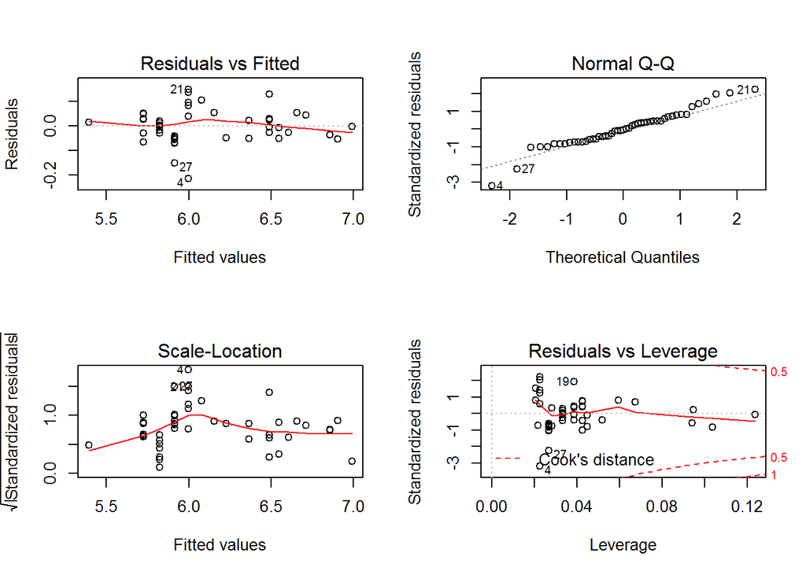

```r
m2 <- lm(logPrice ~ logSize, data = diamonds)
par(mfrow = c(2, 2))
plot(m2)
```

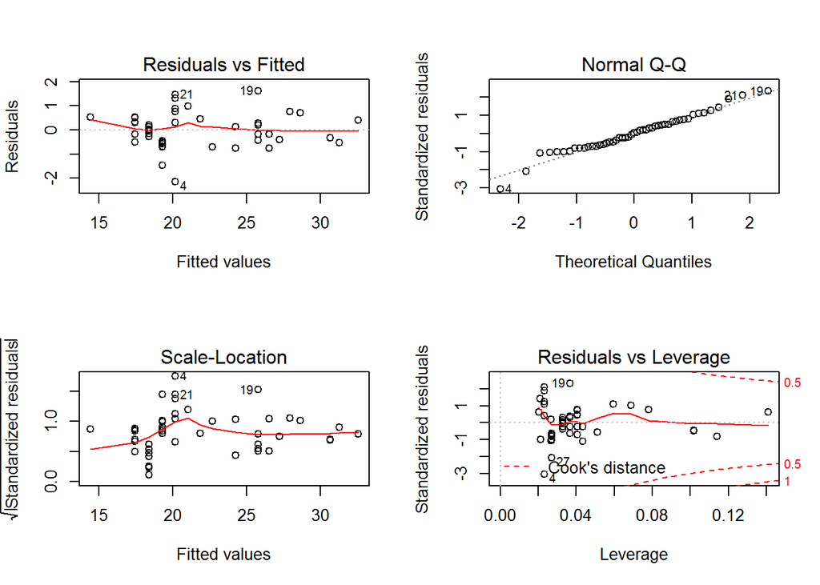

```r
m3 <- lm(sqrtPrice ~ sqrtSize, data = diamonds)
par(mfrow = c(2, 2))
plot(m3)
```

In order to control the variance of the residuals, we consider transformations. There are two models that seem best: the log-log and sqrt-sqrt models. Their residuals plots are very similar, with no non-linearity in the residual plot, fairly normal residuals, and no influential points. Models in which one the predictor or the response were transform led to residual plots that shows a non-linear trend and the variance problem remained.

2. Both transformed models continue to have some issues with constant variance. Specifically, there is a spike around a fitted value of around 450 that persists even in these models.

** Part III** Neither of the models (or actually all three) that we considered is clearly better than the others. All of them may have some issues with constant variance. The transformed models may be *slightly* improved in that regard, so they might be preferred.